None

# Zupee

**Problem Statement:**  
When a user logs in to the platform, they have to choose from a variety of tournament types (A / B / C / D). Additionally, different entry fees may be associated with every tournament. As a platform we must ensure that the most relevant tournaments are suggested to the user based on their preferences.

**Available Data:**  
You will be given anonymised user gameplay data in the form of 3 csv files. Fields in the data are as described below:

*`Gameplay_Data.csv`* contains following fields:

```
● Uid: Alphanumeric unique Id assigned to user
● Eventtime: DateTime on which user played the tournament
● Entry_Fee: Entry Fee of tournament
● Win_Loss: ‘W’ if the user won that particular tournament, ‘L’ otherwise
● Winnings: How much money the user won in the tournament (0 for ‘L’)
● Tournament_Type: Type of tournament user played (A / B / C / D)
● Num_Players: Number of players that played in this tournament
● OOT_holdout: True/False, True indicates the records for the solution evaluation*
*Do not use the Out-of-time holdout data for training
```

*`Wallet_Balance.csv`* contains following fields:

```
● Uid: Alphanumeric unique Id assigned to user
● Timestamp: DateTime at which user’s wallet balance is given
● Wallet_Balance: User’s wallet balance at given time stamp
```

*`Demographic.csv`* contains following fields:

```
● Uid: Alphanumeric unique Id assigned to user
● Installed_At: Timestamp at which user installed the app
● Connection_Type: User’s internet connection type (Ex: Cellular / Dial Up)
● Cpu_Type: Cpu type of device that the user is playing with
● Network_Type: Network type in encoded form
● Device_Manufacturer: Ex: Realme
● ISP: Internet Service Provider. Ex: Airtel
● Country
● Country_Subdivision
● City
● Postal_Code
● Language: Language that user has selected for gameplay
● Device_Name
● Device_Type
```

**Task:**  
Assume that there is a heuristic-based solution already in place that shows the last three user preferences as the top three choices (ordered by recency). Build a recommendation system that is able to rank/recommend relevant tournaments and entry prices to the user while outperforming the current solution in the Out-of-time holdout data -.

The main objectives are:

1. A user should not have to scroll too much before selecting a tournament of their preference
2. We would like to move users to a higher entry fee whenever possible without having an adverse effect on the user experience

As part of your solution, please include the following components:

```
● Code
● Documentation that outlines the solution approach, assumptions, success metrics, and
summary of final results
● Areas of improvement
```

## Import libraries

```python
import os
import numpy as np
import pandas as pd
import amleet as aml
import matplotlib.pyplot as plt
%matplotlib inline

import textwrap
from scipy import sparse
from sklearn.metrics.pairwise import cosine_similarity
from scipy.spatial import distance
from sklearn.manifold import TSNE
# from resources import *

# import lightfm
# from lightfm import LightFM
# from lightfm.lightfm import LightFM
from lightfm.lightfm import LightFM
from lightfm.evaluation import precision_at_k
from lightfm.evaluation import auc_score

# import gensim
from gensim.models.keyedvectors import Word2VecKeyedVectors

#Import Warnings
import warnings
warnings.filterwarnings("ignore")
```

## Configuration

```python
## File Path
gamep_path = './data/new/Gameplay_Data.csv'
balan_path = './data/new/Wallet_Balance.csv'
demog_path = './data/new/Demographic.csv'

# cities_states_path = pkg_resources.resource_filename('amleet', 'aml_files/shp_files/india_cities_states_feb_2015.csv')
# shp_states_path = pkg_resources.resource_filename('amleet', 'aml_files/shp_files/india_states/Indian_states.shp')

## Which Timezone to use
tz_use = 'Asia/Kolkata'
```

## Load data

```python
def shp_and_disp(df, varname):
    print('\n'+'-'*100)
    print('VarName\t:', varname)
    print('Shape\t:', df.shape)
    print('Columns\t:', list(df.columns))
    display(df.head())

## ------------------------------------------<< Gameplay >>------------------------------------------ ##

## 1. GamePlay >>>>> User engagement data
gamep_df = pd.read_csv(gamep_path)
gamep_df.rename(columns={k:k.strip().lower() for k in gamep_df.columns}, inplace=True)
gamep_df['eventtime'] = aml.OperationTime.timestamp_to_datetime(gamep_df['eventtime']/1000, timezone=tz_use)
gamep_df.drop(columns=['unnamed: 0'], inplace=True)

### Creating a column highlighting the total entry fee
gamep_df['total_fee_in_event'] = gamep_df['entry_fee'] * gamep_df['num_players']

### Creating a custom Tournament type.
# - Way 1 - Treating each tournament seperately; without any regard to the amount in tournament
# - Way 2 - Treating each tournament in a way that their rounds are ordinal wrt the amount they are played at
# via way 2 - at the moment no seperation // setting is used
gamep_df['custom_tournament_type'] = aml.Operation.concatenate_cols(
    gamep_df,
    cols_to_combine=['entry_fee', 'tournament_type'],
    sep='||'
)

### Was match won
gamep_df['won'] = [e=='W' for e in gamep_df['win_loss']]

shp_and_disp(gamep_df, aml.variable_name_as_str(gamep_df))

## -------------------------------------------<< Balance >>------------------------------------------ ##

## 2.1. Balance DataFrame >>>>> user transaction data
balan_df = pd.read_csv(balan_path)
balan_df.rename(columns={k:k.strip().lower() for k in balan_df.columns}, inplace=True)
balan_df['timestamp'] = aml.OperationTime.to_datetime(balan_df['timestamp'], timezone=tz_use)
shp_and_disp(balan_df, aml.variable_name_as_str(balan_df))

## 2.2. Users Recent Balance >>>>> user account balance data
### create most recent balance
curr_balance_path = 'proc_balance.csv'
# os.remove(curr_balance_path)
if os.path.exists(curr_balance_path):
    balan_rec_df = pd.read_csv(curr_balance_path)
    balan_rec_df['oldest_timestamp'] = aml.OperationTime.to_datetime(balan_rec_df['oldest_timestamp'], timezone=tz_use)
    balan_rec_df['recent_timestamp'] = aml.OperationTime.to_datetime(balan_rec_df['recent_timestamp'], timezone=tz_use)
else:
    existing_balance_li = []
    for uid in balan_df['uid'].unique():
        temp_df = balan_df.loc[balan_df['uid']==uid, :]
        uid_bal_di = {
            'uid': uid,
            'oldest_timestamp': temp_df['timestamp'].min(),
            'recent_timestamp': temp_df['timestamp'].max(),
            'n_entries': len(temp_df),
            'no_transaction': True if len(temp_df)==1 else False,
            'wallet_balance_min': temp_df['wallet_balance'].min(),
            'wallet_balance_max': temp_df['wallet_balance'].max(),
            'wallet_balance_mean': temp_df['wallet_balance'].mean(),
            'wallet_balance_25quantile': temp_df['wallet_balance'].quantile(.25),
            'wallet_balance_median': temp_df['wallet_balance'].median(),
            'wallet_balance_75quantile': temp_df['wallet_balance'].quantile(.75),
            'wallet_balance_std': temp_df['wallet_balance'].std()
        }
        uid_bal_di['wallet_balance_recent'] = list(temp_df.loc[
            temp_df['timestamp']==uid_bal_di['recent_timestamp'], 'wallet_balance'
        ])[0]
        existing_balance_li.append(uid_bal_di)
    balan_rec_df = pd.DataFrame(existing_balance_li)
    balan_rec_df.loc[balan_rec_df['no_transaction'],'wallet_balance_std']=0
    balan_rec_df.to_csv(curr_balance_path, index=False)
shp_and_disp(balan_rec_df, aml.variable_name_as_str(balan_rec_df))


## -----------------------------------------<< Demographic >>---------------------------------------- ##

## 3.1. Demographic >>>>> user details
demog_df = pd.read_csv(demog_path)
demog_df.rename(columns={k:k.strip().lower() for k in demog_df.columns}, inplace=True)
demog_df['installed_at'] = aml.OperationTime.timestamp_to_datetime(demog_df['installed_at'], timezone=tz_use)
demog_df.drop_duplicates(inplace=True) # duplicate entries were observed
shp_and_disp(demog_df, aml.variable_name_as_str(demog_df))

## 3.2. Unique Demographic Data
print('Total Rows in demographic dataframe\t\t:', len(demog_df))
print('Total unique users in demographic dataframe\t:', len(demog_df['uid'].unique()))
demog_uid_cnt_df = pd.DataFrame(demog_df['uid'].value_counts()).reset_index().rename(columns={'index':'uid', 'uid':'#entries'})
duplicate_entried_uid_li = demog_uid_cnt_df.loc[demog_uid_cnt_df['#entries']>1,'uid'].values.tolist()
display(
    demog_df.loc[[e in duplicate_entried_uid_li for e in demog_df['uid']],:].sort_values(by=['uid']).head(10)
)
print('The reason for this change is difference is that the user has either logged in from different user or he/she has swithed from mode of network.')
### handing the duplicate UID
'''
At the moment to keep data for UID unique; only the datapoint wrt to the UID that are most recent are being kept
- bias introduced for the recent entry
'''
curr_demog_path = 'proc_demog.csv'
# os.remove(curr_demog_path)
if os.path.exists(curr_demog_path):
    demog_rec_df = pd.read_csv(curr_demog_path)
    demog_rec_df['installed_at'] = aml.OperationTime.to_datetime(demog_rec_df['installed_at'], timezone=tz_use)
else:
    ## time was order is not present based on user last usage; therefore in a way random
    demog_df = demog_df.sort_values(by=['uid', 'installed_at'])
    demog_rec_df = demog_df.drop_duplicates(subset=['uid'], keep='last').reset_index(drop=True)
    demog_rec_df.to_csv(curr_demog_path, index=False)
shp_and_disp(demog_rec_df, aml.variable_name_as_str(demog_rec_df))


## --------------------------------------<< User Merged Data >>-------------------------------------- ##

## 4. Performing Inner Join on Demog & Balance
user_merge_df = (
    demog_rec_df
        .rename(columns={k:f'dem_{k}' if k!='uid' else 'uid' for k in demog_rec_df.columns})
        .merge(
            balan_rec_df.rename(columns={k:f'bal_{k}'if k!='uid' else 'uid' for k in balan_rec_df.columns}),
            on=['uid'], how='inner'
        )
)
shp_and_disp(user_merge_df, aml.variable_name_as_str(user_merge_df))
```

```
----------------------------------------------------------------------------------------------------
VarName	: gamep_df
Shape	: (307666, 11)
Columns	: ['uid', 'eventtime', 'entry_fee', 'win_loss', 'winnings', 'tournament_type', 'num_players', 'oot_holdout', 'total_fee_in_event', 'custom_tournament_type', 'won']
```

|  | uid | eventtime | entry_fee | win_loss | winnings | tournament_type | num_players | oot_holdout | total_fee_in_event | custom_tournament_type | won |
| --- | --- | --- | --- | --- | --- | --- | --- | --- | --- | --- | --- |
| 0 | 90976392B3AA5DB94D134936B765879E | 2020-12-07 04:10:30.194000+05:30 | 0.0 | W | 0.1 | D | 4 | False | 0.0 | 0.0\|\|D | True |
| 1 | 7457E894E1F7F1938E55802B964BDD27 | 2020-12-07 02:01:47.669000+05:30 | 10.0 | W | 17.0 | A | 2 | False | 20.0 | 10.0\|\|A | True |
| 2 | 52E43F75D7393581C4E2C5EDC7D24671 | 2020-12-04 00:51:02.845000+05:30 | 35.0 | L | 0.0 | A | 2 | False | 70.0 | 35.0\|\|A | False |
| 3 | 5736C06C66C6BC7036CCE9804F54A57C | 2020-12-12 18:44:35.873000+05:30 | 10.0 | W | 32.0 | B | 4 | False | 40.0 | 10.0\|\|B | True |
| 4 | 5FE2DDA792CA72F731D818A5ECC5F1EB | 2020-12-12 18:39:34.193000+05:30 | 25.0 | W | 42.0 | A | 2 | False | 50.0 | 25.0\|\|A | True |

```
----------------------------------------------------------------------------------------------------
VarName	: balan_df
Shape	: (545835, 3)
Columns	: ['uid', 'timestamp', 'wallet_balance']
```

|  | uid | timestamp | wallet_balance |
| --- | --- | --- | --- |
| 0 | 929A32AC6F614F29BEEA8601BDF0676C | 2020-11-12 11:58:44+05:30 | 10.0 |
| 1 | 929A32AC6F614F29BEEA8601BDF0676C | 2020-11-12 12:02:19+05:30 | 20.0 |
| 2 | 929A32AC6F614F29BEEA8601BDF0676C | 2020-11-12 12:02:38+05:30 | 10.0 |
| 3 | 929A32AC6F614F29BEEA8601BDF0676C | 2020-11-12 12:04:05+05:30 | 20.0 |
| 4 | 929A32AC6F614F29BEEA8601BDF0676C | 2020-11-12 12:04:37+05:30 | 15.0 |

```
----------------------------------------------------------------------------------------------------
VarName	: balan_rec_df
Shape	: (21757, 13)
Columns	: ['uid', 'oldest_timestamp', 'recent_timestamp', 'n_entries', 'no_transaction', 'wallet_balance_min', 'wallet_balance_max', 'wallet_balance_mean', 'wallet_balance_25quantile', 'wallet_balance_median', 'wallet_balance_75quantile', 'wallet_balance_std', 'wallet_balance_recent']
```

|  | uid | oldest_timestamp | recent_timestamp | n_entries | no_transaction | wallet_balance_min | wallet_balance_max | wallet_balance_mean | wallet_balance_25quantile | wallet_balance_median | wallet_balance_75quantile | wallet_balance_std | wallet_balance_recent |
| --- | --- | --- | --- | --- | --- | --- | --- | --- | --- | --- | --- | --- | --- |
| 0 | 929A32AC6F614F29BEEA8601BDF0676C | 2020-11-12 11:58:44+05:30 | 2020-11-14 17:08:58+05:30 | 44 | False | 1.0 | 39.0 | 18.022727 | 10.75 | 18.0 | 23.25 | 8.893396 | 1.0 |
| 1 | 08B4F6235FCE8FF788B2D5CFCC87E27A | 2020-11-20 19:11:54+05:30 | 2020-11-20 19:11:54+05:30 | 1 | True | 10.0 | 10.0 | 10.000000 | 10.00 | 10.0 | 10.00 | 0.000000 | 10.0 |
| 2 | 7393DA09A262621BD04FB9DFEA02951D | 2020-11-21 14:07:16+05:30 | 2020-11-21 14:07:16+05:30 | 1 | True | 10.0 | 10.0 | 10.000000 | 10.00 | 10.0 | 10.00 | 0.000000 | 10.0 |
| 3 | 29E16AE3813E360E52CF236899F4B30D | 2020-11-27 05:25:09+05:30 | 2020-11-27 05:25:09+05:30 | 1 | True | 10.0 | 10.0 | 10.000000 | 10.00 | 10.0 | 10.00 | 0.000000 | 10.0 |
| 4 | D302D8D9AF1B7F6F9ED08D575F103EAB | 2020-11-28 08:41:54+05:30 | 2020-11-28 08:41:54+05:30 | 1 | True | 10.0 | 10.0 | 10.000000 | 10.00 | 10.0 | 10.00 | 0.000000 | 10.0 |

```
----------------------------------------------------------------------------------------------------
VarName	: demog_df
Shape	: (21452, 14)
Columns	: ['uid', 'installed_at', 'connection_type', 'cpu_type', 'network_type', 'device_manufacturer', 'isp', 'country', 'country_subdivision', 'city', 'postal_code', 'language', 'device_name', 'device_type']
```

|  | uid | installed_at | connection_type | cpu_type | network_type | device_manufacturer | isp | country | country_subdivision | city | postal_code | language | device_name | device_type |
| --- | --- | --- | --- | --- | --- | --- | --- | --- | --- | --- | --- | --- | --- | --- |
| 0 | 24CC6E6BA192D1A1EEB320E77F0BF2EE | 2020-12-25 09:32:53+05:30 | Cellular | arm64-v8a | 0 | Realme | Airtel | in | Karnataka | Bengaluru | 560002 | en | XT | phone |
| 1 | 2762F8FB0C406E59DC9D665A4CCEE468 | 2020-12-25 09:35:17+05:30 | Cellular | armeabi-v7a | 0 | Tecno | Jio | in | Bihar | Patna | 800001 | en | TECNOKD7h | phone |
| 2 | 0CF35DBD42AC7013E1A295B5C8E78B0A | 2020-12-25 09:37:05+05:30 | Cellular | arm64-v8a | 0 | Xiaomi | Idea Cellular | in | Tamil Nadu | Chennai | 600012 | en | MiA3 | phone |
| 3 | E829EB3C5A9890718794301564007D91 | 2020-12-25 09:38:01+05:30 | Cellular | arm64-v8a | 13 | vivo | Vodafone India | in | Tamil Nadu | Salem | 636007 | en | vivo1820 | phone |
| 4 | 5BF3652D06CFAF7E811416F1647E597F | 2020-12-25 09:39:39+05:30 | Cellular | arm64-v8a | 13 | Oppo | Jio | in | National Capital Territory of Delhi | New Delhi | 110008 | en | A5s | phone |

```
Total Rows in demographic dataframe		: 21452
Total unique users in demographic dataframe	: 21437
```

|  | uid | installed_at | connection_type | cpu_type | network_type | device_manufacturer | isp | country | country_subdivision | city | postal_code | language | device_name | device_type |
| --- | --- | --- | --- | --- | --- | --- | --- | --- | --- | --- | --- | --- | --- | --- |
| 16633 | 2BC9D9BA88F1DD48E16A27CC2425CF61 | 2020-08-05 17:16:40+05:30 | Cable/DSL | arm64-v8a | 0 | Xiaomi | Excitel | in | National Capital Territory of Delhi | Delhi | 110006 | en | RedmiK20 | phone |
| 16625 | 2BC9D9BA88F1DD48E16A27CC2425CF61 | 2020-08-05 17:16:40+05:30 | Cellular | arm64-v8a | 0 | Xiaomi | Airtel | in | National Capital Territory of Delhi | Delhi | 110054 | en | RedmiK20 | phone |
| 1841 | 32684C2DEB9691573EDC67C3E93B3449 | 2020-12-09 19:35:19+05:30 | Cellular | arm64-v8a | 13 | vivo | Jio | in | West Bengal | Kolkata | 700028 | en | vivo1901 | phone |
| 5832 | 32684C2DEB9691573EDC67C3E93B3449 | 2020-12-09 19:35:19+05:30 | Cellular | arm64-v8a | 13 | vivo | Jio | in | West Bengal | Kolkata | 700059 | en | vivo1901 | phone |
| 1426 | 41243E2847A9BD83AF9E3AE71A0FF0B5 | 2020-12-07 17:14:36+05:30 | Cellular | armeabi-v7a | 13 | Samsung | Jio | in | Bihar | Patna | 800020 | en | GalaxyJ2Core | phone |
| 1430 | 41243E2847A9BD83AF9E3AE71A0FF0B5 | 2020-12-07 17:14:36+05:30 | Cellular | armeabi-v7a | 13 | Samsung | Jio | in | Bihar | Patna | 800001 | en | GalaxyJ2Core | phone |
| 11376 | 414692E57C5090C5E236670A1E95235B | 2020-12-08 20:03:19+05:30 | Cellular | armeabi-v7a | 13 | Xiaomi | Idea Cellular | in | Madhya Pradesh | Indore | 452001 | en | 9 | phone |
| 11374 | 414692E57C5090C5E236670A1E95235B | 2020-12-08 20:03:19+05:30 | Cellular | armeabi-v7a | 13 | Xiaomi | Idea Cellular | in | Madhya Pradesh | Bhopal | 462030 | en | 9 | phone |
| 12849 | 492F5BD0E9F792FCF333B39694A5ACCD | 2020-12-30 21:26:56+05:30 | Cellular | arm64-v8a | 13 | 95390fae98a24199 | Airtel | in | National Capital Territory of Delhi | New Delhi | 110008 | en | 42fa3b0e43be4e61 | tablet |
| 3726 | 492F5BD0E9F792FCF333B39694A5ACCD | 2020-12-30 21:26:56+05:30 | Cellular | arm64-v8a | 13 | 95390fae98a24199 | Idea Cellular | in | Uttarakhand | Ramnagar | 244715 | en | 42fa3b0e43be4e61 | tablet |

```
The reason for this change is difference is that the user has either logged in from different user or he/she has swithed from mode of network.

----------------------------------------------------------------------------------------------------
VarName	: demog_rec_df
Shape	: (21437, 14)
Columns	: ['uid', 'installed_at', 'connection_type', 'cpu_type', 'network_type', 'device_manufacturer', 'isp', 'country', 'country_subdivision', 'city', 'postal_code', 'language', 'device_name', 'device_type']
```

|  | uid | installed_at | connection_type | cpu_type | network_type | device_manufacturer | isp | country | country_subdivision | city | postal_code | language | device_name | device_type |
| --- | --- | --- | --- | --- | --- | --- | --- | --- | --- | --- | --- | --- | --- | --- |
| 0 | 00024680E7379CABB31C1F07A424AB79 | 2020-12-18 10:04:46+05:30 | Cable/DSL | arm64-v8a | 0 | Xiaomi | Mylink Services Pvt Ltd | in | National Capital Territory of Delhi | New Delhi | 110001 | en | Redmi6 | phone |
| 1 | 0002D2CB922C013AAD7B252BF4EFA83B | 2020-12-28 20:31:31+05:30 | Cellular | arm64-v8a | 13 | vivo | Jio | in | Rajasthan | Jaipur | 302001 | hi | vivo1904 | phone |
| 2 | 00033530318B671BDA6D7F32CE89A8DE | 2020-12-24 14:48:14+05:30 | Cellular | arm64-v8a | 13 | vivo | Airtel | in | Bihar | Banka | 813109 | en | vivo1906 | phone |
| 3 | 000396133A80FFC18828139623F9DF45 | 2020-12-20 07:47:13+05:30 | Cellular | arm64-v8a | 13 | Xiaomi | Jio | in | Bihar | Patna | 800001 | en | Redmi3S | phone |
| 4 | 0008CE5E7C84DF55C9887B3C95214681 | 2020-12-27 15:04:21+05:30 | Cellular | armeabi-v7a | 13 | Samsung | Airtel | in | Rajasthan | Jodhpur | 342001 | en | GalaxyA2Core | phone |

```
----------------------------------------------------------------------------------------------------
VarName	: user_merge_df
Shape	: (21428, 26)
Columns	: ['uid', 'dem_installed_at', 'dem_connection_type', 'dem_cpu_type', 'dem_network_type', 'dem_device_manufacturer', 'dem_isp', 'dem_country', 'dem_country_subdivision', 'dem_city', 'dem_postal_code', 'dem_language', 'dem_device_name', 'dem_device_type', 'bal_oldest_timestamp', 'bal_recent_ti…
```

|  | uid | dem_installed_at | dem_connection_type | dem_cpu_type | dem_network_type | dem_device_manufacturer | dem_isp | dem_country | dem_country_subdivision | dem_city | ... | bal_n_entries | bal_no_transaction | bal_wallet_balance_min | bal_wallet_balance_max | bal_wallet_balance_mean | bal_wallet_balance_25quantile | bal_wallet_balance_median | bal_wallet_balance_75quantile | bal_wallet_balance_std | bal_wallet_balance_recent |
| --- | --- | --- | --- | --- | --- | --- | --- | --- | --- | --- | --- | --- | --- | --- | --- | --- | --- | --- | --- | --- | --- |
| 0 | 00024680E7379CABB31C1F07A424AB79 | 2020-12-18 10:04:46+05:30 | Cable/DSL | arm64-v8a | 0 | Xiaomi | Mylink Services Pvt Ltd | in | National Capital Territory of Delhi | New Delhi | ... | 1 | True | 10.0 | 10.0 | 10.0 | 10.0 | 10.0 | 10.0 | 0.0 | 10.0 |
| 1 | 0002D2CB922C013AAD7B252BF4EFA83B | 2020-12-28 20:31:31+05:30 | Cellular | arm64-v8a | 13 | vivo | Jio | in | Rajasthan | Jaipur | ... | 1 | True | 10.0 | 10.0 | 10.0 | 10.0 | 10.0 | 10.0 | 0.0 | 10.0 |
| 2 | 00033530318B671BDA6D7F32CE89A8DE | 2020-12-24 14:48:14+05:30 | Cellular | arm64-v8a | 13 | vivo | Airtel | in | Bihar | Banka | ... | 1 | True | 10.0 | 10.0 | 10.0 | 10.0 | 10.0 | 10.0 | 0.0 | 10.0 |
| 3 | 000396133A80FFC18828139623F9DF45 | 2020-12-20 07:47:13+05:30 | Cellular | arm64-v8a | 13 | Xiaomi | Jio | in | Bihar | Patna | ... | 1 | True | 10.0 | 10.0 | 10.0 | 10.0 | 10.0 | 10.0 | 0.0 | 10.0 |
| 4 | 0008CE5E7C84DF55C9887B3C95214681 | 2020-12-27 15:04:21+05:30 | Cellular | armeabi-v7a | 13 | Samsung | Airtel | in | Rajasthan | Jodhpur | ... | 1 | True | 10.0 | 10.0 | 10.0 | 10.0 | 10.0 | 10.0 | 0.0 | 10.0 |

5 rows × 26 columns

```python
## Analysing the gameplay df tournaments_type
display(aml.Analysis.value_counts_2_cols(gamep_df['tournament_type'], gamep_df['num_players'], True))
display(aml.Analysis.value_counts_2_cols(gamep_df['tournament_type'], gamep_df['entry_fee'], True))

## Overall Winning chance wrt tournament
tt_win_chance_df = aml.Analysis.value_counts_2_cols(gamep_df['tournament_type'], gamep_df['win_loss'], True)
tt_win_chance_df['total'] = tt_win_chance_df['L'] + tt_win_chance_df['W']
tt_win_chance_df['loss_pct'] = round(tt_win_chance_df['L']/tt_win_chance_df['total'],2)
tt_win_chance_df['win_pct'] = round(tt_win_chance_df['W']/tt_win_chance_df['total'],2)
display(tt_win_chance_df)
```

| num_players tournament_type | 2 | 4 |
| --- | --- | --- |
| A | 180639 |  |
| B |  | 6862 |
| C |  | 27274 |
| D |  | 92891 |

| entry_fee tournament_type | 0.0 | 1.0 | 5.0 | 10.0 | 15.0 | 25.0 | 35.0 | 50.0 | 100.0 | 250.0 | 500.0 | 1000.0 | 5000.0 | 10000.0 |
| --- | --- | --- | --- | --- | --- | --- | --- | --- | --- | --- | --- | --- | --- | --- |
| A | 265 | 113056 |  | 34528 |  | 14556 | 1876 | 6863 | 6149 | 2084 | 756 | 481 | 24 | 1 |
| B |  |  |  | 6862 |  |  |  |  |  |  |  |  |  |  |
| C |  |  |  | 16753 |  | 866 | 4559 | 2058 | 3038 |  |  |  |  |  |
| D | 63325 |  | 26658 |  | 2908 |  |  |  |  |  |  |  |  |  |

| win_loss tournament_type | L | W | total | loss_pct | win_pct |
| --- | --- | --- | --- | --- | --- |
| A | 94461 | 86178 | 180639 | 0.52 | 0.48 |
| B | 5304 | 1558 | 6862 | 0.77 | 0.23 |
| C | 14462 | 12812 | 27274 | 0.53 | 0.47 |
| D | 25203 | 67688 | 92891 | 0.27 | 0.73 |

```python
## Calculate individual user Win rate wrt to CTT
temp_gamep_df = gamep_df.loc[gamep_df['oot_holdout']==False,:]
user_winrate_df = temp_gamep_df \
    .groupby(['uid', 'custom_tournament_type', 'entry_fee', 'tournament_type', 'num_players'])['won'] \
    .count().reset_index().rename(columns={'won':'total_usr_sessions'}).join(
    temp_gamep_df.groupby(['uid', 'custom_tournament_type'])['won'].sum(),
    on=['uid', 'custom_tournament_type'], how='inner'
).rename(columns={'won':'sessions_won'})
user_winrate_df['win_rate'] = user_winrate_df['sessions_won']/user_winrate_df['total_usr_sessions']
user_winrate_df['total_fee_by_user'] = user_winrate_df['total_usr_sessions'] * user_winrate_df['entry_fee']
display(user_winrate_df.head())

# gamep_df = pd.merge(gamep_df, user_winrate_df.drop(columns=['won']),
#     on=['uid', 'custom_tournament_type']
# )
# display(gamep_df.tail())

## creating df for similiaratity generation
usr_ctt_df = pd.merge(user_winrate_df, user_merge_df, on=['uid'], how='inner')
usr_ctt_df['dem_device_manufacturer'] = [e.lower() for e in usr_ctt_df['dem_device_manufacturer']]
usr_ctt_df['bal_no_transaction'] = [1 if e is True else 0 for e in usr_ctt_df['bal_no_transaction']]
display(usr_ctt_df.tail())
```

|  | uid | custom_tournament_type | entry_fee | tournament_type | num_players | total_usr_sessions | sessions_won | win_rate | total_fee_by_user |
| --- | --- | --- | --- | --- | --- | --- | --- | --- | --- |
| 0 | 0012CB6DA8CB360BA4ACC6A40F2C5E7D | 0.0\|\|D | 0.0 | D | 4 | 9 | 8 | 0.888889 | 0.0 |
| 1 | 0012CB6DA8CB360BA4ACC6A40F2C5E7D | 1.0\|\|A | 1.0 | A | 2 | 26 | 13 | 0.500000 | 26.0 |
| 2 | 0012CB6DA8CB360BA4ACC6A40F2C5E7D | 10.0\|\|A | 10.0 | A | 2 | 3 | 2 | 0.666667 | 30.0 |
| 3 | 0016F36E9D87DC1C1D8FCA7F84648122 | 1.0\|\|A | 1.0 | A | 2 | 58 | 26 | 0.448276 | 58.0 |
| 4 | 0016F36E9D87DC1C1D8FCA7F84648122 | 10.0\|\|A | 10.0 | A | 2 | 5 | 2 | 0.400000 | 50.0 |

|  | uid | custom_tournament_type | entry_fee | tournament_type | num_players | total_usr_sessions | sessions_won | win_rate | total_fee_by_user | dem_installed_at | ... | bal_n_entries | bal_no_transaction | bal_wallet_balance_min | bal_wallet_balance_max | bal_wallet_balance_mean | bal_wallet_balance_25quantile | bal_wallet_balance_median | bal_wallet_balance_75quantile | bal_wallet_balance_std | bal_wallet_balance_recent |
| --- | --- | --- | --- | --- | --- | --- | --- | --- | --- | --- | --- | --- | --- | --- | --- | --- | --- | --- | --- | --- | --- |
| 28390 | FFF4ADEDA6D8C7DECBE3A8712FB8FAC4 | 0.0\|\|D | 0.0 | D | 4 | 1 | 1 | 1.000000 | 0.0 | 2020-12-12 10:46:16+05:30 | ... | 1 | 1 | 10.0 | 10.0 | 10.000000 | 10.0 | 10.0 | 10.0 | 0.000000 | 10.0 |
| 28391 | FFF5374F5BA9E8D96FEFC94A2E7476E5 | 0.0\|\|D | 0.0 | D | 4 | 3 | 3 | 1.000000 | 0.0 | 2020-12-04 22:05:49+05:30 | ... | 143 | 0 | 1.0 | 37.0 | 9.216783 | 5.0 | 7.0 | 9.5 | 7.047265 | 4.0 |
| 28392 | FFF5374F5BA9E8D96FEFC94A2E7476E5 | 1.0\|\|A | 1.0 | A | 2 | 64 | 33 | 0.515625 | 64.0 | 2020-12-04 22:05:49+05:30 | ... | 143 | 0 | 1.0 | 37.0 | 9.216783 | 5.0 | 7.0 | 9.5 | 7.047265 | 4.0 |
| 28393 | FFF5374F5BA9E8D96FEFC94A2E7476E5 | 10.0\|\|C | 10.0 | C | 4 | 10 | 3 | 0.300000 | 100.0 | 2020-12-04 22:05:49+05:30 | ... | 143 | 0 | 1.0 | 37.0 | 9.216783 | 5.0 | 7.0 | 9.5 | 7.047265 | 4.0 |
| 28394 | FFF5374F5BA9E8D96FEFC94A2E7476E5 | 5.0\|\|D | 5.0 | D | 4 | 7 | 3 | 0.428571 | 35.0 | 2020-12-04 22:05:49+05:30 | ... | 143 | 0 | 1.0 | 37.0 | 9.216783 | 5.0 | 7.0 | 9.5 | 7.047265 | 4.0 |

5 rows × 34 columns

```python
## Data prep
identi_cols = [
    'uid', 'custom_tournament_type', 'entry_fee', 'tournament_type',
    'num_players', 'total_usr_sessions', 'sessions_won',
]
quant_cols = ['win_rate', 'total_fee_by_user',
    'dem_cpu_type', 'dem_network_type',
    'dem_country', 'dem_language', 'dem_device_type',
    'bal_n_entries',
    'bal_no_transaction', 'bal_wallet_balance_min',
    'bal_wallet_balance_max', 'bal_wallet_balance_mean',
    'bal_wallet_balance_median',
    'bal_wallet_balance_std',]
drop_cols = [
    'dem_installed_at', 'dem_city', 'dem_postal_code', 'dem_country_subdivision',
    'dem_isp', 'dem_connection_type', 'dem_device_manufacturer', 'dem_device_name',
    'bal_oldest_timestamp', 'bal_recent_timestamp', 'bal_wallet_balance_25quantile',
    'bal_wallet_balance_75quantile', 'bal_wallet_balance_recent'
] ## for ease at the moment - Missing data among other things


## Drop columns
usr_ctt_df.drop(columns=drop_cols, inplace=True)

## One Hot Encode Columns
usr_ctt_encoded_df = pd.get_dummies(
    usr_ctt_df,
    columns=['dem_cpu_type', 'dem_network_type', 'dem_country', 'dem_language', 'dem_device_type'])
usr_ctt_encoded_df.head()
```

|  | uid | custom_tournament_type | entry_fee | tournament_type | num_players | total_usr_sessions | sessions_won | win_rate | total_fee_by_user | bal_n_entries | ... | dem_country_sg | dem_country_us | dem_language_bn | dem_language_en | dem_language_gu | dem_language_hi | dem_language_mr | dem_device_type_phone | dem_device_type_tablet | dem_device_type_tv |
| --- | --- | --- | --- | --- | --- | --- | --- | --- | --- | --- | --- | --- | --- | --- | --- | --- | --- | --- | --- | --- | --- |
| 0 | 0012CB6DA8CB360BA4ACC6A40F2C5E7D | 0.0\|\|D | 0.0 | D | 4 | 9 | 8 | 0.888889 | 0.0 | 59 | ... | 0 | 0 | 0 | 1 | 0 | 0 | 0 | 1 | 0 | 0 |
| 1 | 0012CB6DA8CB360BA4ACC6A40F2C5E7D | 1.0\|\|A | 1.0 | A | 2 | 26 | 13 | 0.500000 | 26.0 | 59 | ... | 0 | 0 | 0 | 1 | 0 | 0 | 0 | 1 | 0 | 0 |
| 2 | 0012CB6DA8CB360BA4ACC6A40F2C5E7D | 10.0\|\|A | 10.0 | A | 2 | 3 | 2 | 0.666667 | 30.0 | 59 | ... | 0 | 0 | 0 | 1 | 0 | 0 | 0 | 1 | 0 | 0 |
| 3 | 0016F36E9D87DC1C1D8FCA7F84648122 | 1.0\|\|A | 1.0 | A | 2 | 58 | 26 | 0.448276 | 58.0 | 102 | ... | 0 | 0 | 0 | 1 | 0 | 0 | 0 | 1 | 0 | 0 |
| 4 | 0016F36E9D87DC1C1D8FCA7F84648122 | 10.0\|\|A | 10.0 | A | 2 | 5 | 2 | 0.400000 | 50.0 | 102 | ... | 0 | 0 | 0 | 1 | 0 | 0 | 0 | 1 | 0 | 0 |

5 rows × 46 columns

```python
df_info = aml.DataPrimAnalysis(usr_ctt_encoded_df.head(), True).run()
```

```
Overall dataset shape : (5, 46)
____________| Number of feature/s which are Qualitative : 3 |____________
```

|  | IsNullSum | dtypes | IsNaSum | count | unique | top | freq | CategoriesName | %Missing |
| --- | --- | --- | --- | --- | --- | --- | --- | --- | --- |
| uid | 0 | object | 0 | 5 | 2 | 0012CB6DA8CB360BA4ACC6A40F2C5E7D | 3 | [0012CB6DA8CB360BA4ACC6A40F2C5E7D, 0016F36E9D8... | 0.0 |
| custom_tournament_type | 0 | object | 0 | 5 | 3 | 1.0\|\|A | 2 | [0.0\|\|D, 1.0\|\|A, 10.0\|\|A] | 0.0 |
| tournament_type | 0 | object | 0 | 5 | 2 | A | 4 | [D, A] | 0.0 |

```
____________| Number of feature/s which are Quantitative : 13 |____________
```

|  | IsNullSum | dtypes | IsNaSum | count | mean | std | min | 25% | 50% | 75% | max | %Missing |
| --- | --- | --- | --- | --- | --- | --- | --- | --- | --- | --- | --- | --- |
| entry_fee | 0 | float64 | 0 | 5.0 | 4.400000 | 5.128353 | 0.000000 | 1.000000 | 1.000000 | 10.000000 | 10.000000 | 0.0 |
| num_players | 0 | int64 | 0 | 5.0 | 2.400000 | 0.894427 | 2.000000 | 2.000000 | 2.000000 | 2.000000 | 4.000000 | 0.0 |
| total_usr_sessions | 0 | int64 | 0 | 5.0 | 20.200000 | 22.993477 | 3.000000 | 5.000000 | 9.000000 | 26.000000 | 58.000000 | 0.0 |
| sessions_won | 0 | int64 | 0 | 5.0 | 10.200000 | 9.959920 | 2.000000 | 2.000000 | 8.000000 | 13.000000 | 26.000000 | 0.0 |
| win_rate | 0 | float64 | 0 | 5.0 | 0.580766 | 0.199419 | 0.400000 | 0.448276 | 0.500000 | 0.666667 | 0.888889 | 0.0 |
| total_fee_by_user | 0 | float64 | 0 | 5.0 | 32.800000 | 22.698018 | 0.000000 | 26.000000 | 30.000000 | 50.000000 | 58.000000 | 0.0 |
| bal_n_entries | 0 | int64 | 0 | 5.0 | 76.200000 | 23.552070 | 59.000000 | 59.000000 | 59.000000 | 102.000000 | 102.000000 | 0.0 |
| bal_no_transaction | 0 | int64 | 0 | 5.0 | 0.000000 | 0.000000 | 0.000000 | 0.000000 | 0.000000 | 0.000000 | 0.000000 | 0.0 |
| bal_wallet_balance_min | 0 | float64 | 0 | 5.0 | 4.200000 | 1.095445 | 3.000000 | 3.000000 | 5.000000 | 5.000000 | 5.000000 | 0.0 |
| bal_wallet_balance_max | 0 | float64 | 0 | 5.0 | 38.200000 | 4.381780 | 35.000000 | 35.000000 | 35.000000 | 43.000000 | 43.000000 | 0.0 |
| bal_wallet_balance_mean | 0 | float64 | 0 | 5.0 | 20.609904 | 1.949157 | 19.186441 | 19.186441 | 19.186441 | 22.745098 | 22.745098 | 0.0 |
| bal_wallet_balance_median | 0 | float64 | 0 | 5.0 | 19.600000 | 2.190890 | 18.000000 | 18.000000 | 18.000000 | 22.000000 | 22.000000 | 0.0 |
| bal_wallet_balance_std | 0 | float64 | 0 | 5.0 | 6.614666 | 0.461560 | 6.109052 | 6.109052 | 6.951741 | 6.951741 | 6.951741 | 0.0 |

```
Some columns data is missing b/c of data type
len(temp)!= (len(temp_tim) + len(temp_cat) + len(temp_num))
46 != (0 + 3+ 13)
Columns not part of this: ['dem_cpu_type_arm64-v8a', 'dem_cpu_type_armeabi-v7a', 'dem_cpu_type_x86', 'dem_cpu_type_x86_64', 'dem_network_type_0', 'dem_network_type_1', 'dem_network_type_2', 'dem_network_type_3', 'dem_network_type_8', 'dem_network_type_9', 'dem_network_type_10', 'dem_network_type_13'…
```

```python
## Encode UID (User ID) & CTT (Custom Tournament Type)

## Encode User ID
user_ids = usr_ctt_encoded_df['uid'].unique().tolist()
user2user_encoded = {x: i for i, x in enumerate(user_ids)}
user_encoded2user = {i: x for i, x in enumerate(user_ids)}
usr_ctt_encoded_df['uid'] = usr_ctt_encoded_df['uid'].map(user2user_encoded)
n_users = len(user2user_encoded)

## Encode Tournament Type
ctt_ids = usr_ctt_encoded_df['custom_tournament_type'].unique().tolist()
ctt2ctt_encoded = {x: i for i, x in enumerate(ctt_ids)}
ctt_encoded2ctt = {i: x for i, x in enumerate(ctt_ids)}
usr_ctt_encoded_df['custom_tournament_type'] = usr_ctt_encoded_df['custom_tournament_type'].map(ctt2ctt_encoded)
n_ctt = len(ctt2ctt_encoded)

shp_and_disp(usr_ctt_encoded_df, aml.variable_name_as_str(usr_ctt_encoded_df))

mssg = f'Info\n\t# Users\t\t\t\t:{n_users}\n\t# Custom Tournament Types\t:{n_ctt}' \
    f'\n\tTotal Tournament Fee by user\n\t\tMin \t: {usr_ctt_encoded_df["total_fee_by_user"].min()}\n\t\t' \
    f'Median\t: {usr_ctt_encoded_df["total_fee_by_user"].quantile(0.5)}\n\t\t' \
    f'Mean \t: {usr_ctt_encoded_df["total_fee_by_user"].mean()}\n\t\t' \
    f'Max \t: {usr_ctt_encoded_df["total_fee_by_user"].max()}\n\t\t'
print(mssg)
```

```
----------------------------------------------------------------------------------------------------
VarName	: usr_ctt_encoded_df
Shape	: (28395, 46)
Columns	: ['uid', 'custom_tournament_type', 'entry_fee', 'tournament_type', 'num_players', 'total_usr_sessions', 'sessions_won', 'win_rate', 'total_fee_by_user', 'bal_n_entries', 'bal_no_transaction', 'bal_wallet_balance_min', 'bal_wallet_balance_max', 'bal_wallet_balance_mean', 'bal_wallet_balance_…
```

|  | uid | custom_tournament_type | entry_fee | tournament_type | num_players | total_usr_sessions | sessions_won | win_rate | total_fee_by_user | bal_n_entries | ... | dem_country_sg | dem_country_us | dem_language_bn | dem_language_en | dem_language_gu | dem_language_hi | dem_language_mr | dem_device_type_phone | dem_device_type_tablet | dem_device_type_tv |
| --- | --- | --- | --- | --- | --- | --- | --- | --- | --- | --- | --- | --- | --- | --- | --- | --- | --- | --- | --- | --- | --- |
| 0 | 0 | 0 | 0.0 | D | 4 | 9 | 8 | 0.888889 | 0.0 | 59 | ... | 0 | 0 | 0 | 1 | 0 | 0 | 0 | 1 | 0 | 0 |
| 1 | 0 | 1 | 1.0 | A | 2 | 26 | 13 | 0.500000 | 26.0 | 59 | ... | 0 | 0 | 0 | 1 | 0 | 0 | 0 | 1 | 0 | 0 |
| 2 | 0 | 2 | 10.0 | A | 2 | 3 | 2 | 0.666667 | 30.0 | 59 | ... | 0 | 0 | 0 | 1 | 0 | 0 | 0 | 1 | 0 | 0 |
| 3 | 1 | 1 | 1.0 | A | 2 | 58 | 26 | 0.448276 | 58.0 | 102 | ... | 0 | 0 | 0 | 1 | 0 | 0 | 0 | 1 | 0 | 0 |
| 4 | 1 | 2 | 10.0 | A | 2 | 5 | 2 | 0.400000 | 50.0 | 102 | ... | 0 | 0 | 0 | 1 | 0 | 0 | 0 | 1 | 0 | 0 |

5 rows × 46 columns

```
Info
	# Users				:9387
	# Custom Tournament Types	:21
	Total Tournament Fee by user
		Min 	: 0.0
		Median	: 16.0
		Mean 	: 134.14171509068498
		Max 	: 70000.0
```

```python
## Creating User-Tournament Interaction Matrix with win rate as filling criteria; -1 represent not played
pd.crosstab(
    usr_ctt_encoded_df['uid'],
    usr_ctt_encoded_df['custom_tournament_type'],
    usr_ctt_encoded_df['win_rate'],
    aggfunc=np.max
).fillna(-1)
```

| custom_tournament_type uid | 0 | 1 | 2 | 3 | 4 | 5 | 6 | 7 | 8 | 9 | ... | 11 | 12 | 13 | 14 | 15 | 16 | 17 | 18 | 19 | 20 |
| --- | --- | --- | --- | --- | --- | --- | --- | --- | --- | --- | --- | --- | --- | --- | --- | --- | --- | --- | --- | --- | --- |
| 0 | 0.888889 | 0.500000 | 0.666667 | -1.0 | -1.0 | -1.000000 | -1.0 | -1.0 | -1.0 | -1.0 | ... | -1.0 | -1.0 | -1.0 | -1.0 | -1.0 | -1.0 | -1.0 | -1.0 | -1.0 | -1.0 |
| 1 | -1.000000 | 0.448276 | 0.400000 | 1.0 | 0.0 | 0.500000 | -1.0 | -1.0 | -1.0 | -1.0 | ... | -1.0 | -1.0 | -1.0 | -1.0 | -1.0 | -1.0 | -1.0 | -1.0 | -1.0 | -1.0 |
| 2 | 1.000000 | -1.000000 | -1.000000 | -1.0 | -1.0 | -1.000000 | -1.0 | -1.0 | -1.0 | -1.0 | ... | -1.0 | -1.0 | -1.0 | -1.0 | -1.0 | -1.0 | -1.0 | -1.0 | -1.0 | -1.0 |
| 3 | 0.000000 | -1.000000 | -1.000000 | -1.0 | -1.0 | -1.000000 | -1.0 | -1.0 | -1.0 | -1.0 | ... | -1.0 | -1.0 | -1.0 | -1.0 | -1.0 | -1.0 | -1.0 | -1.0 | -1.0 | -1.0 |
| 4 | -1.000000 | -1.000000 | -1.000000 | -1.0 | -1.0 | -1.000000 | 0.0 | -1.0 | -1.0 | -1.0 | ... | -1.0 | -1.0 | -1.0 | -1.0 | -1.0 | -1.0 | -1.0 | -1.0 | -1.0 | -1.0 |
| ... | ... | ... | ... | ... | ... | ... | ... | ... | ... | ... | ... | ... | ... | ... | ... | ... | ... | ... | ... | ... | ... |
| 9382 | 1.000000 | -1.000000 | -1.000000 | -1.0 | -1.0 | -1.000000 | -1.0 | -1.0 | -1.0 | -1.0 | ... | -1.0 | -1.0 | -1.0 | -1.0 | -1.0 | -1.0 | -1.0 | -1.0 | -1.0 | -1.0 |
| 9383 | -1.000000 | -1.000000 | -1.000000 | -1.0 | -1.0 | -1.000000 | 0.0 | -1.0 | -1.0 | -1.0 | ... | -1.0 | -1.0 | -1.0 | -1.0 | -1.0 | -1.0 | -1.0 | -1.0 | -1.0 | -1.0 |
| 9384 | -1.000000 | 0.777778 | -1.000000 | -1.0 | -1.0 | 0.500000 | -1.0 | -1.0 | -1.0 | -1.0 | ... | -1.0 | -1.0 | -1.0 | -1.0 | -1.0 | -1.0 | -1.0 | -1.0 | -1.0 | -1.0 |
| 9385 | 1.000000 | -1.000000 | -1.000000 | -1.0 | -1.0 | -1.000000 | -1.0 | -1.0 | -1.0 | -1.0 | ... | -1.0 | -1.0 | -1.0 | -1.0 | -1.0 | -1.0 | -1.0 | -1.0 | -1.0 | -1.0 |
| 9386 | 1.000000 | 0.515625 | -1.000000 | -1.0 | 0.3 | 0.428571 | -1.0 | -1.0 | -1.0 | -1.0 | ... | -1.0 | -1.0 | -1.0 | -1.0 | -1.0 | -1.0 | -1.0 | -1.0 | -1.0 | -1.0 |

9387 rows × 21 columns

```python
## predicting user win rate -- encoding layer will be extracted from inbetween

# Shuffle
usr_ctt_encoded_df = usr_ctt_encoded_df.sample(frac=1, random_state=73)

# Split - based on OOT
# x_cols = ['uid', 'custom_tournament_type']
# identi_cols
# x_cols_user = [e for e in usr_ctt_encoded_df.columns if e not in identi_cols]
x_cols = ['uid', 'custom_tournament_type']
x_cols_user = [
    'total_usr_sessions', 'sessions_won', 'win_rate',
    'total_fee_by_user', 'bal_n_entries', 'bal_no_transaction',
    'bal_wallet_balance_min', 'bal_wallet_balance_max',
    'bal_wallet_balance_mean', 'bal_wallet_balance_median',
    'bal_wallet_balance_std', 'dem_cpu_type_arm64-v8a',
    'dem_cpu_type_armeabi-v7a', 'dem_cpu_type_x86', 'dem_cpu_type_x86_64',
    'dem_network_type_0', 'dem_network_type_1', 'dem_network_type_2',
    'dem_network_type_3', 'dem_network_type_8', 'dem_network_type_9',
    'dem_network_type_10', 'dem_network_type_13', 'dem_network_type_15',
    'dem_network_type_18', 'dem_network_type_19', 'dem_country_ch',
    'dem_country_gb', 'dem_country_ie', 'dem_country_in', 'dem_country_np',
    'dem_country_sg', 'dem_country_us', 'dem_language_bn',
    'dem_language_en', 'dem_language_gu', 'dem_language_hi',
    'dem_language_mr', 'dem_device_type_phone', 'dem_device_type_tablet',
    'dem_device_type_tv'
]
x_cols_ctt = ['num_players'] # 'entry_fee', 'tournament_type',
y_col = 'win_rate'
xy_set = usr_ctt_encoded_df.loc[:, x_cols+x_cols_user+x_cols_ctt+[y_col]]
```

```python
# Removing Duplicated Rows
duplicates = xy_set.duplicated()
if duplicates.sum() > 0:
    print('> {} duplicates'.format(duplicates.sum()))
    xy_set = xy_set[~duplicates]

# x_train = xy_set.loc[xy_set['oot_holdout']==False, x_cols].values
# y_train = xy_set.loc[xy_set['oot_holdout']==False, y_col]
# x_test = xy_set.loc[xy_set['oot_holdout']==True, x_cols].values
# y_test = xy_set.loc[xy_set['oot_holdout']==True, y_col]

## all are from 'oot_holdout'==False
x_train = xy_set.loc[:, x_cols+x_cols_user+x_cols_ctt].values
y_train = xy_set.loc[:, y_col]

print('> Train set size\t: {}'.format(len(y_train)))
print(x_train.shape)
# print('> Test set size\t\t: {}'.format(len(y_test)))

x_train_array = [x_train[:, 0], x_train[:, 1], x_train[:,2:]]
# x_test_array = [x_test[:, 0], x_test[:, 1]]

# y_train = np.array(y_train.astype('float32'))#.reshape((-1,1))
# y_test = np.array(y_test.astype('float32'))#.reshape((-1,1))
```

```
> Train set size	: 28395
(28395, 45)
```

```
Model: "model"
__________________________________________________________________________________________________
 Layer (type)                   Output Shape         Param #     Connected to
==================================================================================================
 user (InputLayer)              [(None, 1)]          0           []

 tournament_type (InputLayer)   [(None, 1)]          0           []

 user_embedding (Embedding)     (None, 1, 128)       1201536     ['user[0][0]']

 tourn_embedding (Embedding)    (None, 1, 128)       2688        ['tournament_type[0][0]']

 dot_product (Dot)              (None, 1, 1)         0           ['user_embedding[0][0]',
                                                                  'tourn_embedding[0][0]']

 user_ctt_data (InputLayer)     [(None, 43)]         0           []

 flatten (Flatten)              (None, 1)            0           ['dot_product[0][0]']

 dense (Dense)                  (None, 16)           704         ['user_ctt_data[0][0]']

 concatenate (Concatenate)      (None, 17)           0           ['flatten[0][0]',
                                                                  'dense[0][0]']

 dense_1 (Dense)                (None, 8)            144         ['concatenate[0][0]']

 batch_normalization (BatchNorm  (None, 8)           32          ['dense_1[0][0]']
 alization)

 dense_2 (Dense)                (None, 1)            9           ['batch_normalization[0][0]']

 batch_normalization_1 (BatchNo  (None, 1)           4           ['dense_2[0][0]']
 rmalization)

 activation (Activation)        (None, 1)            0           ['batch_normalization_1[0][0]']

==================================================================================================
Total params: 1,205,117
Trainable params: 1,205,099
Non-trainable params: 18
__________________________________________________________________________________________________
```

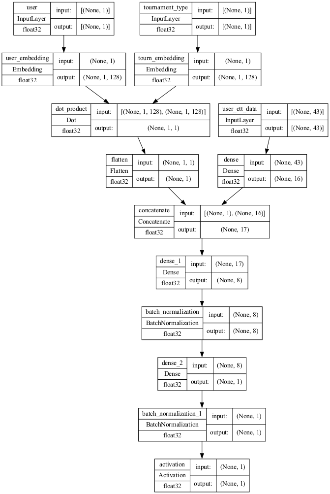

```
[Error] Unable to get output when running "psutil.cpu_freq()"

──────────────────────────────────────────────────────────────────────
Neural Network Memory Requirements
├── Internal Models in the Architecture
│   └── 0 bytes
│       0.0 B
├── Shapes of the Architecture
│   └── (memory required for all layer shapes) x (batch size) bytes
│       1420 x 32 bytes
│       45440 bytes
│       44.4 KB
└── Model Weights
    ├── Trainable
    │   └── (parameters) x (memory for each) bytes
    │       1205099 x 4 bytes
    │       4820396 bytes
    │       4.6 MB
    └── Non-Trainable
        └── (parameters) x (memory for each) bytes
            18 x 4 bytes
            72 bytes
            72.0 B
──────────────────────────────────────────────────────────────────────
Total Memory Requirement : 4865908 bytes : 4.6 MB
Available RAM : 12.5 GB
──────────────────────────────────────────────────────────────────────
```

```python
### Building a basic model to to generate wts and encodings
## Loading Libs
import tensorflow as tf
from tensorflow.keras import layers
from tensorflow.keras.models import Model
from tensorflow.keras.optimizers import Adam

# Embedding layers
from tensorflow.keras.layers import (
    Add, Activation, Lambda, BatchNormalization, Concatenate, Dropout,
    Input, Embedding, Dot, Reshape, Dense, Flatten
)

def RecommenderNet(n_users, n_ctt):
    '''
    Custom Recommender Net
    '''
    embedding_size = 128

    ## Input Layers
    user = Input(name='user', shape = [1])
    tour = Input(name='tournament_type', shape = [1])
    usr_ctt = Input(name='user_ctt_data', shape = (43,))

    ## Embedding Layers
    user_embedding = Embedding(
        input_dim=n_users, output_dim=embedding_size, name='user_embedding'
    )(user)
    tour_embedding = Embedding(
        input_dim=n_ctt, output_dim=embedding_size, name='tourn_embedding'
    )(tour)
    # print(user_embedding.shape, tour_embedding.shape, usr_ctt.shape)

    x1 = Dot(name = 'dot_product', normalize = True, axes = 2)([user_embedding, tour_embedding])
    x1 = Flatten()(x1)
    x2 = Dense(16, kernel_initializer='he_normal')(usr_ctt)
    x = Concatenate()([x1, x2])
#     x1 = Dense(1, kernel_initializer='he_normal')(x1)
#     x1 = BatchNormalization()(x1)
#     x2 = BatchNormalization()(x2)
#     x = Flatten()(x)
    x = Dense(8, kernel_initializer='he_normal')(x)
    x = BatchNormalization()(x)
    x = Dense(1, kernel_initializer='he_normal')(x)
    x = BatchNormalization()(x)

    x = Activation("sigmoid")(x)
    model = Model(inputs=[user, tour, usr_ctt], outputs=x)
    model.compile(loss='mean_absolute_error', metrics=["mae", "mse"], optimizer='Adam')
    return model

model = RecommenderNet(n_users, n_ctt)
# model.summary()
try:
    aml.aml13_keras.describe_keras_model(model)
except:
    aml.capture_exception()

_ = aml.aml13_keras.get_memory_usage_by_keras_model(model)
```

```python
# [print(i.shape, i.dtype) for i in model.inputs]

# [print(o.shape, o.dtype) for o in model.outputs]

# [print(l.name, l.input_shape, l.dtype) for l in model.layers]

# aml.aml13_keras.get_keras_metrics()
```

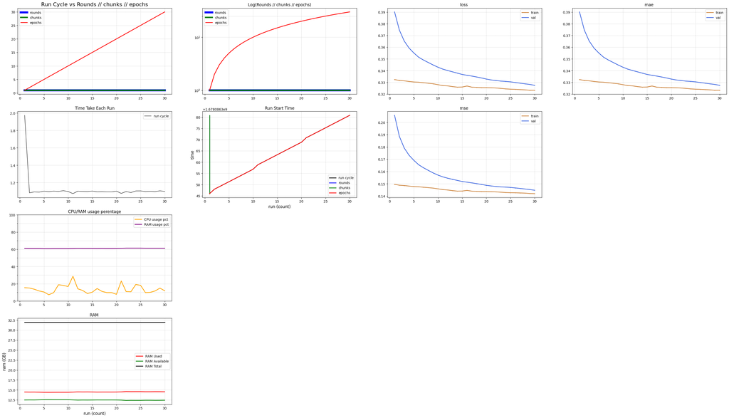

```
# =======================================<<<  TRAINING END  >>>======================================= #
```

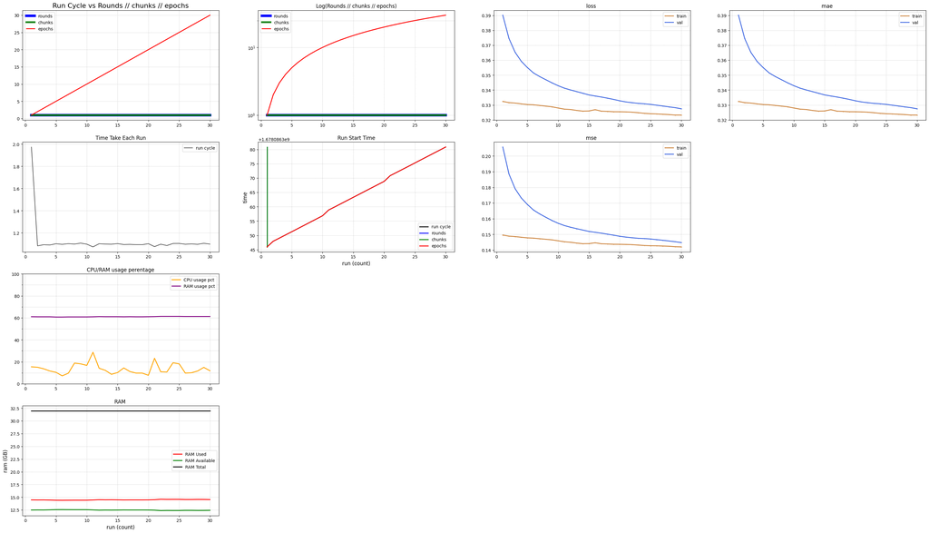

[output not shown]

```python
total_round = 1
total_chunk = 1
total_epoch = 30
batch_size = 10000

# > ((None, 1) vs (None, 2))

print('# ======================================<<<  TRAINING START  >>>====================================== #')
log_info = aml.LogTrainingInfo()
for which_round in range(1, total_round+1):  # shuffle the data here
    for which_chunk in range(1, total_chunk+1):  # use data generator here
        # model.fit(X_train, y_train, batch_size=32, epochs=20)
        # # ...continue training with a larger batch size
        # model.fit(X_train, y_train, batch_size=512, epochs=10)
        history = model.fit(
            x_train_array,
            y_train,
            epochs=total_epoch,
            validation_split=0.20,
            batch_size=batch_size,
            verbose=0,
            callbacks=[
                aml.TrainingLogsCallback(
                    batch_size, which_round, which_chunk,
                    total_round, total_chunk, total_epoch,
                    info_log_instance=log_info,
                    plot_info_graph=True
                )
            ]
        )
print('# =======================================<<<  TRAINING END  >>>======================================= #')

log_info.plot_training_logs()
print(log_info.all_logs[:3])
```

```python
model.save('./weights.h5')
# model = keras.models.load_model('path/to/location')
```

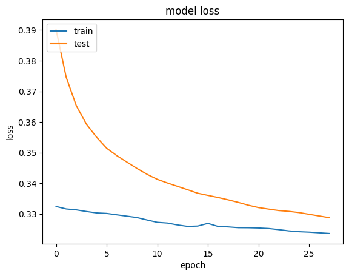

```python
#Training results
import matplotlib.pyplot as plt
%matplotlib inline

plt.plot(history.history["loss"][0:-2])
plt.plot(history.history["val_loss"][0:-2])
plt.title("model loss")
plt.ylabel("loss")
plt.xlabel("epoch")
plt.legend(["train", "test"], loc="upper left")
plt.show()
```

```python
## Extracting Wts from Model
def extract_weights(name, model):
    weight_layer = model.get_layer(name)
    weights = weight_layer.get_weights()[0]
    weights = weights / np.linalg.norm(weights, axis = 1).reshape((-1, 1))
    return weights

user_weights = extract_weights('user_embedding', model)
tourn_weights = extract_weights('tourn_embedding', model)
```

## Finding Similiar Users

```python
#pd.reset_option('all')
pd.set_option("max_colwidth", None)

def find_similar_users(user_index_or_id, n=10, return_dist=False, neg=False, verbose=1):
    '''
    '''
    n = n+1

    # global variable: user_encoded2user, user2user_encoded, user_weights
    ## Get the UID and User Index
    try:
        if isinstance(user_index_or_id, int):
            user_id = user_encoded2user[user_index_or_id]
            user_index = user_index_or_id
        else:
            user_id = user_index_or_id
            user_index = user2user_encoded[user_index_or_id]
        print(f"User Details:\n\tUID\t: {user_id}\n\tUIndex\t: {user_index}")
    except:
        raise Exception(f'user_index_or_id "{user_index_or_id}" doesn\'t exist in the dataset')

    ##
    dists = np.dot(user_weights, user_weights[user_index])
    sorted_dists = np.argsort(dists)

    ## Order
    if neg:
        closest = sorted_dists[:n]
    else:
        closest = sorted_dists[-n:]

    if verbose!=0:
        print('> users similar to {}'.format(user_id))

    if return_dist:
        return dists, closest

    SimilarityArr = []
    for close_user_index in closest:
        similarity = dists[close_user_index]
        close_user_id = user_encoded2user[close_user_index]
        SimilarityArr.append({
            'similar_user_index': close_user_index,
            'similar_user_uid': close_user_id,
            'similarity': similarity}
        )

    Frame = pd.DataFrame(SimilarityArr).sort_values(
        by='similarity', ascending=False)

    return Frame

## Sample run
user_index_or_id = "A521433C2E99EE46311AD23AD216A16E"
find_similar_users(user_index_or_id, n=5, return_dist=False, neg=False)
```

```
User Details:
	UID	: A521433C2E99EE46311AD23AD216A16E
	UIndex	: 6143
> users similar to A521433C2E99EE46311AD23AD216A16E
```

|  | similar_user_index | similar_user_uid | similarity |
| --- | --- | --- | --- |
| 5 | 6143 | A521433C2E99EE46311AD23AD216A16E | 1.000000 |
| 4 | 5612 | 97624528A338B59EBBA8515CA8B36E61 | 0.350541 |
| 3 | 7276 | C490DE80D10E0F63CA403C38930D9CFF | 0.349284 |
| 2 | 5065 | 87D5C0B334B39896095D67AFFFA4FD57 | 0.316877 |
| 1 | 3700 | 63586E9FF88DE336B3BDB30CABD391F1 | 0.314399 |
| 0 | 6032 | A2832AA6731541FB0AF05D3F48C25A84 | 0.276736 |

```python
## Sample run
user_index_or_id = 10
find_similar_users(user_index_or_id, n=5, return_dist=False, neg=False)
```

```
User Details:
	UID	: 0047154B9561205DBBBD1F68D89E0A72
	UIndex	: 10
> users similar to 0047154B9561205DBBBD1F68D89E0A72
```

|  | similar_user_index | similar_user_uid | similarity |
| --- | --- | --- | --- |
| 5 | 10 | 0047154B9561205DBBBD1F68D89E0A72 | 1.000000 |
| 4 | 9374 | FF9D71867425EF8FFC73B9849447DD70 | 0.322795 |
| 3 | 1547 | 2B0AB58DDD0F89A62CD8D83F70DD699C | 0.293159 |
| 2 | 7592 | CCA70E40D8AD561B2AFC429678E58480 | 0.291980 |
| 1 | 2646 | 48D3C191D8AE29B3A4FB389CD6EE5D6A | 0.289204 |
| 0 | 8060 | DA44E3271E26B4A762D3D67F5AEC27D3 | 0.289147 |

```python
print('> picking up random user')

gamep_per_user = gamep_df.groupby('uid').size()
random_user = gamep_per_user[gamep_per_user < 500].sample(1, random_state=None).index[0]
print('> user_id:', random_user)
```

```
> picking up random user
> user_id: 226A6A5432F26A280D180EFD1D4DE58E
```

```python
similar_users = find_similar_users(random_user, n=5, neg=False)

# similar_users = similar_users[similar_users['similarity'] > 0.4]
similar_users = similar_users[similar_users['similar_user_index']!=random_user]
similar_users.head(5)
```

```
User Details:
	UID	: 226A6A5432F26A280D180EFD1D4DE58E
	UIndex	: 1225
> users similar to 226A6A5432F26A280D180EFD1D4DE58E
```

|  | similar_user_index | similar_user_uid | similarity |
| --- | --- | --- | --- |
| 5 | 1225 | 226A6A5432F26A280D180EFD1D4DE58E | 1.000000 |
| 4 | 8522 | E7E793EB1A5D431BB2C3E9F0B37BB81F | 0.321714 |
| 3 | 5747 | 9AD6C34FBBBD56C6E62FBC1B070F5206 | 0.308103 |
| 2 | 2482 | 44063EAA4BF7A133025633A77BEF2B4E | 0.299102 |
| 1 | 7381 | C729E2E0679684AF6CC0D4DBA53D6A5E | 0.295784 |

## Finding Similiar Tournament

```python
# pd.reset_option('all')
pd.set_option("max_colwidth", None)

def find_similar_tours(tour_index_or_id, n=10, return_dist=False, neg=False, has_higher_value=False):
    '''
    '''
    n = n+1
    n_dash = n
    if has_higher_value: n=None

    # global variable: ctt_encoded2ctt, ctt2ctt_encoded, tourn_weights
    ## Get the UID and tour Index
    try:
        if isinstance(tour_index_or_id, int):
            tour_id = ctt_encoded2ctt[tour_index_or_id]
            tour_index = tour_index_or_id
        else:
            tour_id = tour_index_or_id
            tour_index = ctt2ctt_encoded[tour_index_or_id]
        tour_entry_fee, tour_name = tour_id.split('||')
        tour_entry_fee = float(tour_entry_fee)
        print(f"tour Details:\n\tTID\t: {tour_id}\n\tUIndex\t: {tour_index}\n\tEntryFee: {tour_entry_fee}\n\ttour name: {tour_name}")
    except:
        raise Exception(f'tour_index_or_id "{tour_index_or_id}" doesn\'t exist in the dataset')

    ##
    dists = np.dot(tourn_weights, tourn_weights[tour_index])
    sorted_dists = np.argsort(dists)

    ## Order
    if neg:
        closest = sorted_dists[:n]
    else:
        closest = sorted_dists[::-1][:n][::-1]

    print('> tours similar to {}'.format(tour_id))

    if return_dist:
        return dists, closest

    SimilarityArr = []
    for close_tour_index in closest:
        similarity = dists[close_tour_index]
        close_tour_id = ctt_encoded2ctt[close_tour_index]
        close_tour_entry_fee, close_tour_name = close_tour_id.split('||')
        close_tour_entry_fee = float(close_tour_entry_fee)
        temp_di = {
            'similar_tour_index': close_tour_index,
            'similar_tour_ctt': close_tour_id,
            'similar_tour_entry_fee': close_tour_entry_fee,
            'similar_tour_tour_name': close_tour_name,
            'similarity': similarity
        }

        # print(tour_id, close_tour_id, tour_id==close_tour_id, similarity)
        if has_higher_value:
            if close_tour_entry_fee>=tour_entry_fee:
                SimilarityArr.append(temp_di)
        else:
            SimilarityArr.append(temp_di)

    recomm_df = pd.DataFrame(SimilarityArr).sort_values(
        by='similarity', ascending=False)[:n_dash]

    if has_higher_value:
        ''' ## heuristic score development
        temp_df['heuristic_score'] = temp_df['similarity']*temp_df['similar_tour_entry_fee']
        ref_heuristic_score = temp_df.loc[temp_df['similar_tour_ctt']==tour_id, 'heuristic_score'].values[0]
        temp_df['heuristic_score_closeness'] = abs(temp_df['heuristic_score'] - ref_heuristic_score)
        temp_df.sort_values(by='heuristic_score_closeness', ascending=True, inplace=True)
        temp_df.drop(columns=['heuristic_score', 'heuristic_score_closeness'], inplace=True)
        '''
        recomm_df.sort_values(by=['similar_tour_entry_fee', 'similarity'], ascending=True, inplace=True)

    return recomm_df

## Sample run - has_higher_value=False
tour_index_or_id = 5
temp_df = find_similar_tours(tour_index_or_id, n=5, return_dist=False, neg=False, has_higher_value=False)
temp_df
```

```
tour Details:
	TID	: 5.0||D
	UIndex	: 5
	EntryFee: 5.0
	tour name: D
> tours similar to 5.0||D
```

|  | similar_tour_index | similar_tour_ctt | similar_tour_entry_fee | similar_tour_tour_name | similarity |
| --- | --- | --- | --- | --- | --- |
| 5 | 5 | 5.0\|\|D | 5.0 | D | 1.000000 |
| 4 | 16 | 250.0\|\|A | 250.0 | A | 0.265845 |
| 3 | 12 | 35.0\|\|C | 35.0 | C | 0.251507 |
| 2 | 15 | 500.0\|\|A | 500.0 | A | 0.158227 |
| 1 | 1 | 1.0\|\|A | 1.0 | A | 0.134142 |
| 0 | 10 | 100.0\|\|C | 100.0 | C | 0.119632 |

```python
## Sample run - has_higher_value=True
tour_index_or_id = 5
temp_df = find_similar_tours(tour_index_or_id, n=5, return_dist=False, neg=False, has_higher_value=True)
temp_df
```

```
tour Details:
	TID	: 5.0||D
	UIndex	: 5
	EntryFee: 5.0
	tour name: D
> tours similar to 5.0||D
```

|  | similar_tour_index | similar_tour_ctt | similar_tour_entry_fee | similar_tour_tour_name | similarity |
| --- | --- | --- | --- | --- | --- |
| 17 | 5 | 5.0\|\|D | 5.0 | D | 1.000000 |
| 12 | 2 | 10.0\|\|A | 10.0 | A | 0.117260 |
| 15 | 12 | 35.0\|\|C | 35.0 | C | 0.251507 |
| 13 | 10 | 100.0\|\|C | 100.0 | C | 0.119632 |
| 16 | 16 | 250.0\|\|A | 250.0 | A | 0.265845 |
| 14 | 15 | 500.0\|\|A | 500.0 | A | 0.158227 |

```python
## Sample run
tour_index_or_id = 10
temp_df = find_similar_tours(tour_index_or_id, n=5, return_dist=False, neg=False, has_higher_value=False)
temp_df
```

```
tour Details:
	TID	: 100.0||C
	UIndex	: 10
	EntryFee: 100.0
	tour name: C
> tours similar to 100.0||C
```

|  | similar_tour_index | similar_tour_ctt | similar_tour_entry_fee | similar_tour_tour_name | similarity |
| --- | --- | --- | --- | --- | --- |
| 5 | 10 | 100.0\|\|C | 100.0 | C | 1.000000 |
| 4 | 13 | 50.0\|\|C | 50.0 | C | 0.189832 |
| 3 | 1 | 1.0\|\|A | 1.0 | A | 0.185993 |
| 2 | 14 | 100.0\|\|A | 100.0 | A | 0.141888 |
| 1 | 2 | 10.0\|\|A | 10.0 | A | 0.131360 |
| 0 | 5 | 5.0\|\|D | 5.0 | D | 0.119632 |

```python
## Sample run
tour_index_or_id = 10
temp_df = find_similar_tours(tour_index_or_id, n=5, return_dist=False, neg=False, has_higher_value=True)
temp_df
```

```
tour Details:
	TID	: 100.0||C
	UIndex	: 10
	EntryFee: 100.0
	tour name: C
> tours similar to 100.0||C
```

|  | similar_tour_index | similar_tour_ctt | similar_tour_entry_fee | similar_tour_tour_name | similarity |
| --- | --- | --- | --- | --- | --- |
| 5 | 14 | 100.0\|\|A | 100.0 | A | 0.141888 |
| 6 | 10 | 100.0\|\|C | 100.0 | C | 1.000000 |
| 3 | 16 | 250.0\|\|A | 250.0 | A | 0.028737 |
| 2 | 15 | 500.0\|\|A | 500.0 | A | 0.027622 |
| 1 | 18 | 1000.0\|\|A | 1000.0 | A | 0.025268 |
| 4 | 19 | 5000.0\|\|A | 5000.0 | A | 0.076433 |

```python
## Sample run
tour_index_or_id = 15
temp_df = find_similar_tours(tour_index_or_id, n=5, return_dist=False, neg=False, has_higher_value=False)
temp_df
```

```
tour Details:
	TID	: 500.0||A
	UIndex	: 15
	EntryFee: 500.0
	tour name: A
> tours similar to 500.0||A
```

|  | similar_tour_index | similar_tour_ctt | similar_tour_entry_fee | similar_tour_tour_name | similarity |
| --- | --- | --- | --- | --- | --- |
| 5 | 15 | 500.0\|\|A | 500.0 | A | 1.000000 |
| 4 | 16 | 250.0\|\|A | 250.0 | A | 0.197297 |
| 3 | 1 | 1.0\|\|A | 1.0 | A | 0.166863 |
| 2 | 5 | 5.0\|\|D | 5.0 | D | 0.158227 |
| 1 | 14 | 100.0\|\|A | 100.0 | A | 0.080733 |
| 0 | 7 | 25.0\|\|A | 25.0 | A | 0.054475 |

```python
## Sample run
tour_index_or_id = 15
temp_df = find_similar_tours(tour_index_or_id, n=5, return_dist=False, neg=False, has_higher_value=True)
temp_df
```

```
tour Details:
	TID	: 500.0||A
	UIndex	: 15
	EntryFee: 500.0
	tour name: A
> tours similar to 500.0||A
```

|  | similar_tour_index | similar_tour_ctt | similar_tour_entry_fee | similar_tour_tour_name | similarity |
| --- | --- | --- | --- | --- | --- |
| 3 | 15 | 500.0\|\|A | 500.0 | A | 1.000000 |
| 1 | 18 | 1000.0\|\|A | 1000.0 | A | -0.000810 |
| 0 | 19 | 5000.0\|\|A | 5000.0 | A | -0.068002 |
| 2 | 20 | 10000.0\|\|A | 10000.0 | A | 0.040068 |

## User preferences

```
User Details:
	UID	: 05FE9BE08F7028A366254F6D134E184B
	UIndex	: 200
> preferred custom_tournament_type
```

|  | custom_tournament_type | freq |
| --- | --- | --- |
| 0 | 1.0\|\|A | 464 |
| 1 | 5.0\|\|D | 61 |
| 2 | 0.0\|\|D | 25 |
| 3 | 10.0\|\|A | 2 |
| 4 | 10.0\|\|C | 2 |

```
No artists with labels found to put in legend.  Note that artists whose label start with an underscore are ignored when legend() is called with no argument.
```

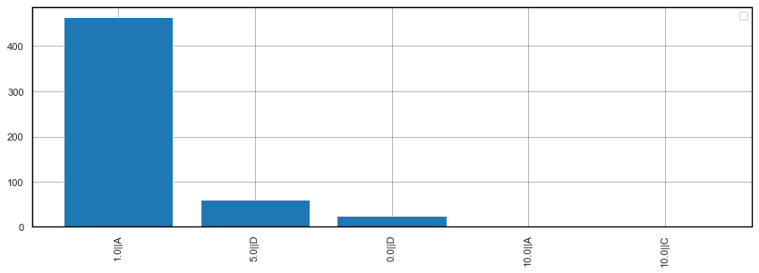

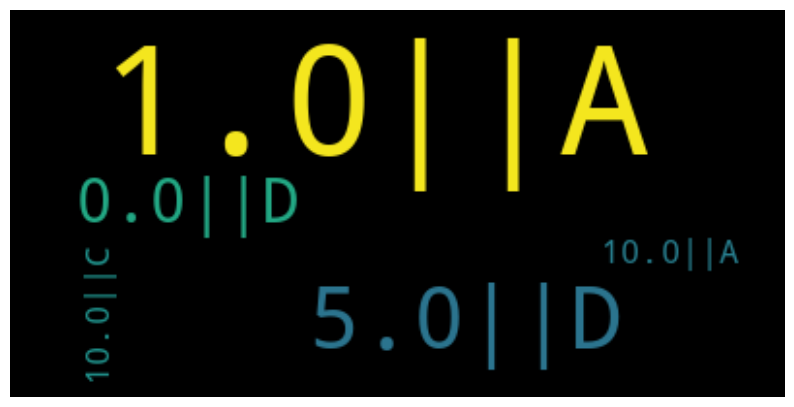

```
1.0||A     464
5.0||D      61
0.0||D      25
10.0||A      2
10.0||C      2
Name: custom_tournament_type, dtype: int64
```

```python
from wordcloud import WordCloud
from collections import defaultdict
import matplotlib.pyplot as plt

def get_user_preferences(user_index_or_id, plot=False, verbose=0):
    '''
    '''
    # global variable: user_encoded2user, user2user_encoded
    ## Get the UID and User Index
    try:
        if isinstance(user_index_or_id, int):
            user_id = user_encoded2user[user_index_or_id]
            user_index = user_index_or_id
        else:
            user_id = user_index_or_id
            user_index = user2user_encoded[user_index_or_id]
    except:
        raise Exception(f'user_index_or_id "{user_index_or_id}" doesn\'t exist in the dataset')

    ctt_played_by_user = gamep_df.loc[gamep_df['uid']==user_id,'custom_tournament_type'].value_counts()

    if verbose != 0:
        # print(f'> User ID : {user_id}')
        print(f"User Details:\n\tUID\t: {user_id}\n\tUIndex\t: {user_index}")
        print('> preferred custom_tournament_type')
        display(
            pd.DataFrame(ctt_played_by_user).reset_index().rename(
                columns={'index': 'custom_tournament_type', 'custom_tournament_type': 'freq'})
        )

    if plot:
        aml.plotBivariate_NumCat(
            ctt_played_by_user.index,
            ctt_played_by_user.values,
            plt_type='bar',
            rotate_x_tick=90
        )
        ## wordcloud plot
        genres_cloud = WordCloud(
#             width=300, height=150, background_color='white', colormap='gnuplot'
        ).generate_from_frequencies(ctt_played_by_user)

        plt.figure(figsize=(10,8))
        plt.imshow(genres_cloud, interpolation='bilinear')
        plt.axis('off')
        plt.show()

    return ctt_played_by_user


# user_index_or_id = '90976392B3AA5DB94D134936B765879E'
# get_user_preferences(user_index_or_id, plot=True, verbose=1)

user_index_or_id = 200
get_user_preferences(user_index_or_id, plot=True, verbose=1)
```

## Recommending Tournament to the users

```python
def get_tournament_recommendation(
    user_index_or_id=10, recommend_from_played=True, n_recommendations=5, has_higher_value=False,
    verbose=0
):
    '''
    Desc:
        Get user name and recommend the tournamnet recommendations
    Input:
        user_index_or_id: user id or index
            UID	: 032D8AE6EE070AF808AF708EEECFDCC3
            UIndex	: 100
        recommend_from_played: Wheather to recommend the user the games he/she have already played or not
        n_recommendations: Number of recommendation to return to the user
        has_higher_value: Returns recommendation with bias towards spending more by the user.
    Return:
        Sorted Df with recommendations
    '''
    ## find similiar user
    similar_users = find_similar_users(user_index_or_id, n=n_recommendations, neg=False, verbose=0)
    similar_users = similar_users[similar_users['similarity'] > 0.2]
    similar_users = similar_users[similar_users['similar_user_index']!=user_index_or_id]
    # similar_users.head(5)

    ## find user preference
    ser = None
    for uid in similar_users['similar_user_uid']:
        usr_pref_li = get_user_preferences(uid, plot=False, verbose=0)
        if recommend_from_played is False:
            already_played_li = gamep_df.loc[gamep_df['uid']==user_id,'custom_tournament_type'].unique().tolist()
            usr_pref_li = usr_pref_li.loc[~usr_pref_li.index.isin(already_played_li)]
        if ser is None:
            ser = usr_pref_li
        else:
            ser = ser.add(usr_pref_li, fill_value=0)

    ## create recommended df
    recommed_df = pd.DataFrame(ser).reset_index().rename(
        columns={'index': 'custom_tournament_type', 'custom_tournament_type':'close_user_played_freq'}
    ).sort_values(by=['close_user_played_freq'], ascending=False)
    recommed_df['tournament_type'] = [e.split('||')[-1] for e in recommed_df['custom_tournament_type']]
    recommed_df['entry_fee'] = [float(e.split('||')[0]) for e in recommed_df['custom_tournament_type']]
    if verbose != 0:
        print('Initial Recommendation')
        display(recommed_df)

    ## User Balance History
    usr_bal_df = user_merge_df.loc[user_merge_df['uid']==uid,:]
    usr_bal_df = usr_bal_df.loc[:,[col for col in usr_bal_df.columns if (('bal_' in col) or (col in ['uid']))]]
    usr_bal_df.reset_index(drop=True, inplace=True)
    if verbose != 0:
        print(f'USER "{uid}" Balance History')
        display(usr_bal_df.loc[0,:])

    ## average money spend by the user
    usr_total_spend = usr_ctt_df.loc[usr_ctt_df['uid']==uid, 'total_fee_by_user'].sum()
    usr_total_session = usr_ctt_df.loc[usr_ctt_df['uid']==uid, 'total_usr_sessions'].sum()
    usr_spend_avg = usr_total_spend / usr_total_session
    if verbose != 0:
        print('Average Money spend by User :', usr_spend_avg)
        if has_higher_value:
            print('"Spend More" bias has been added. Hence 2 out of 5 recommenation will have higer entry fees, in addition to taste matching.')

    ## Recommend atleast 2 tournament in top 5 where entry_fee is greater than usr_spend_avg
    recommended_tour_li = []
    cnt_spend_greater = 0
    recommed_df.reset_index(drop=True, inplace=True)
    for index,row in recommed_df.iterrows():
        if has_higher_value:
            if row['entry_fee']>=usr_spend_avg:
                cnt_spend_greater+=1
            if len(recommed_df)>5:
                if ((index>=3) & (cnt_spend_greater==0)):
                    continue
                if ((index>=4) & (cnt_spend_greater==1)):
                    continue
        recommended_tour_li.append({
            'custom_tournament_type': row['custom_tournament_type'],
            'tournament_type': row['tournament_type'],
            'entry_fee': row['entry_fee'],
        })

    # recommed_df.loc[recommed_df['entry_fee']>=usr_spend_avg]
    return pd.DataFrame(recommended_tour_li)[:n_recommendations]
```

```python
user_index_or_id = '226A6A5432F26A280D180EFD1D4DE58E'
user_index_or_id = 100

recommendation_df = get_tournament_recommendation(
    user_index_or_id, recommend_from_played=True, n_recommendations=5, has_higher_value=False,
    verbose=0
)
print('\nRecommended tournaments')
recommendation_df
```

```
User Details:
	UID	: 032D8AE6EE070AF808AF708EEECFDCC3
	UIndex	: 100

Recommended tournaments
```

|  | custom_tournament_type | tournament_type | entry_fee |
| --- | --- | --- | --- |
| 0 | 10.0\|\|B | B | 10.0 |
| 1 | 25.0\|\|A | A | 25.0 |
| 2 | 100.0\|\|C | C | 100.0 |
| 3 | 35.0\|\|C | C | 35.0 |
| 4 | 1.0\|\|A | A | 1.0 |

```python
# user_index_or_id = '226A6A5432F26A280D180EFD1D4DE58E'
user_index_or_id = 100

recommendation_df = get_tournament_recommendation(
    user_index_or_id, recommend_from_played=True, n_recommendations=5, has_higher_value=True,
    verbose=1
)
print('\nRecommended tournaments')
recommendation_df
```

```
User Details:
	UID	: 032D8AE6EE070AF808AF708EEECFDCC3
	UIndex	: 100
Initial Recommendation
```

|  | custom_tournament_type | close_user_played_freq | tournament_type | entry_fee |
| --- | --- | --- | --- | --- |
| 4 | 10.0\|\|B | 127.0 | B | 10.0 |
| 8 | 25.0\|\|A | 127.0 | A | 25.0 |
| 7 | 100.0\|\|C | 121.0 | C | 100.0 |
| 10 | 35.0\|\|C | 106.0 | C | 35.0 |
| 2 | 1.0\|\|A | 98.0 | A | 1.0 |
| 6 | 100.0\|\|A | 80.0 | A | 100.0 |
| 12 | 50.0\|\|A | 80.0 | A | 50.0 |
| 3 | 10.0\|\|A | 73.0 | A | 10.0 |
| 13 | 50.0\|\|C | 73.0 | C | 50.0 |
| 1 | 0.0\|\|D | 72.0 | D | 0.0 |
| 5 | 10.0\|\|C | 25.0 | C | 10.0 |
| 11 | 5.0\|\|D | 22.0 | D | 5.0 |
| 9 | 250.0\|\|A | 10.0 | A | 250.0 |
| 0 | 0.0\|\|A | 1.0 | A | 0.0 |

```
USER "E29046F1EF241429D29B1C473FFFE472" Balance History
```

```
uid                              E29046F1EF241429D29B1C473FFFE472
bal_oldest_timestamp                    2020-12-08 12:59:42+05:30
bal_recent_timestamp                    2021-01-07 02:29:33+05:30
bal_n_entries                                                1454
bal_no_transaction                                          False
bal_wallet_balance_min                                       -7.0
bal_wallet_balance_max                                     1325.0
bal_wallet_balance_mean                                273.077717
bal_wallet_balance_25quantile                                39.0
bal_wallet_balance_median                                   148.0
bal_wallet_balance_75quantile                               490.0
bal_wallet_balance_std                                 279.386786
bal_wallet_balance_recent                                     1.0
Name: 0, dtype: object
```

```
Average Money spend by User : 46.038167938931295
"Spend More" bias has been added. Hence 2 out of 5 recommenation will have higer entry fees, in addition to taste matching.

Recommended tournaments
```

|  | custom_tournament_type | tournament_type | entry_fee |
| --- | --- | --- | --- |
| 0 | 10.0\|\|B | B | 10.0 |
| 1 | 25.0\|\|A | A | 25.0 |
| 2 | 100.0\|\|C | C | 100.0 |
| 3 | 35.0\|\|C | C | 35.0 |
| 4 | 100.0\|\|A | A | 100.0 |

```python
user_index_or_id = '0BF2E10E7600479E6AFAD35EE60DC313'
# user_index_or_id = 100

recommendation_df = get_tournament_recommendation(
    user_index_or_id, recommend_from_played=True, n_recommendations=5, has_higher_value=True,
    verbose=1
)
print('\nRecommended tournaments')
recommendation_df
```

```
User Details:
	UID	: 0BF2E10E7600479E6AFAD35EE60DC313
	UIndex	: 440
Initial Recommendation
```

|  | custom_tournament_type | close_user_played_freq | tournament_type | entry_fee |
| --- | --- | --- | --- | --- |
| 1 | 1.0\|\|A | 53.0 | A | 1.0 |
| 0 | 0.0\|\|D | 49.0 | D | 0.0 |
| 5 | 5.0\|\|D | 39.0 | D | 5.0 |
| 2 | 10.0\|\|A | 3.0 | A | 10.0 |
| 4 | 10.0\|\|C | 2.0 | C | 10.0 |
| 3 | 10.0\|\|B | 1.0 | B | 10.0 |

```
USER "BF0ECB1E8A31308FCF0B01FA94A6E50A" Balance History
```

```
uid                              BF0ECB1E8A31308FCF0B01FA94A6E50A
bal_oldest_timestamp                    2020-12-03 16:03:36+05:30
bal_recent_timestamp                    2020-12-26 22:53:13+05:30
bal_n_entries                                                  53
bal_no_transaction                                          False
bal_wallet_balance_min                                        2.0
bal_wallet_balance_max                                       38.0
bal_wallet_balance_mean                                 10.811321
bal_wallet_balance_25quantile                                 6.0
bal_wallet_balance_median                                     9.0
bal_wallet_balance_75quantile                                14.0
bal_wallet_balance_std                                   7.468026
bal_wallet_balance_recent                                     2.0
Name: 0, dtype: object
```

```
Average Money spend by User : 3.5625
"Spend More" bias has been added. Hence 2 out of 5 recommenation will have higer entry fees, in addition to taste matching.

Recommended tournaments
```

|  | custom_tournament_type | tournament_type | entry_fee |
| --- | --- | --- | --- |
| 0 | 1.0\|\|A | A | 1.0 |
| 1 | 0.0\|\|D | D | 0.0 |
| 2 | 5.0\|\|D | D | 5.0 |
| 3 | 10.0\|\|A | A | 10.0 |
| 4 | 10.0\|\|C | C | 10.0 |